# Lab 7: Data Tidying Transformation & Visualization with COVID-19 reporting data

Author

Marina Duclos

```r
library(tidyverse)
library(lubridate)
library(readr)
library(dplyr)
library(ggplot2)
library(gganimate)
library(gifski)
```

```r
if (!dir.exists("data")) {
  dir.create("data")
}
```

```r
url <- "https://raw.githubusercontent.com/CSSEGISandData/COVID-19/master/csse_covid_19_data/csse_covid_19_time_series/time_series_covid19_deaths_global.csv"
download.file(url, destfile = "data/time_series_covid19_deaths_global.csv")
```

```r
download.file(
  url = "https://raw.githubusercontent.com/CSSEGISandData/COVID-19/master/csse_covid_19_data/csse_covid_19_time_series/time_series_covid19_confirmed_global.csv",
  destfile = "data/time_series_covid19_confirmed_global.csv"
)

#| eval: false
```

```r
library(readr)
library(dplyr)

time_series_confirmed <- read_csv("data/time_series_covid19_confirmed_global.csv") %>%
  rename(Province_State = "Province/State", Country_Region = "Country/Region")
```

# Exercise 1: Chapter 5.2.1 Exercises

## Question 1

For each of the sample tables, describe what each observation and each column represents.

### Table 1

The observations represent one country in one year.

The columns:

country → name of the country

year → the year of the observation was made

cases → # of TB cases

population → population of the country that year

### Table 2

The observations represent one measurement for one country in one year, could be cases or populations

The columns:

country → name of the country

year → the year of the observation was made

type → the type of measurment made such as cases or population

count → value of measurement

### Table 3

The observations represent one country in one year.

The columns:

country → name of the country

year → the year of the observation was made

rate → string combining cases & population

## Question 2

Sketch out the process you’d use to calculate the rate for table2 and table3. You will need to perform four operations:

1. Extract the number of TB cases per country per year.
2. Extract the matching population per country per year.
3. Divide cases by population, and multiply by 10000.
4. Store back in the appropriate place.

### Table 2.

```r
cases <- table2 |> filter(type == "cases")
population <- table2 |> filter(type == "population")

joined <- left_join(cases, population, by = c("country", "year"), suffix = c("_cases", "_pop"))

joined |> mutate(rate = count_cases / count_pop * 10000)
```

```
# A tibble: 6 × 7
  country      year type_cases count_cases type_pop    count_pop  rate
  <chr>       <dbl> <chr>            <dbl> <chr>           <dbl> <dbl>
1 Afghanistan  1999 cases              745 population   19987071 0.373
2 Afghanistan  2000 cases             2666 population   20595360 1.29
3 Brazil       1999 cases            37737 population  172006362 2.19
4 Brazil       2000 cases            80488 population  174504898 4.61
5 China        1999 cases           212258 population 1272915272 1.67
6 China        2000 cases           213766 population 1280428583 1.67
```

### Table 3

```r
table3 |>
  separate(rate, into = c("cases", "population"), sep = "/") |>
  mutate(
    cases = as.numeric(cases),
    population = as.numeric(population),
    rate = cases / population * 10000
  )
```

```
# A tibble: 6 × 5
  country      year  cases population  rate
  <chr>       <dbl>  <dbl>      <dbl> <dbl>
1 Afghanistan  1999    745   19987071 0.373
2 Afghanistan  2000   2666   20595360 1.29
3 Brazil       1999  37737  172006362 2.19
4 Brazil       2000  80488  174504898 4.61
5 China        1999 212258 1272915272 1.67
6 China        2000 213766 1280428583 1.67
```

# Exercise 2

Instead of making a graph of 5 countries on the same graph as in the above example, use facet_wrap with scales=“free_y”.

```r
titime_series_confirmed <- read_csv("data/time_series_covid19_confirmed_global.csv") %>%
  rename(Province_State = `Province/State`, Country_Region = `Country/Region`)
```

```r
time_series_confirmed_long <- time_series_confirmed %>%
  pivot_longer(
    cols = matches("^\\d"),  # selects all date columns
    names_to = "Date",       # new column for date names
    values_to = "Confirmed"  # new column for case counts
  ) %>%
  mutate(Date = mdy(Date))   # convert date strings to Date format
```

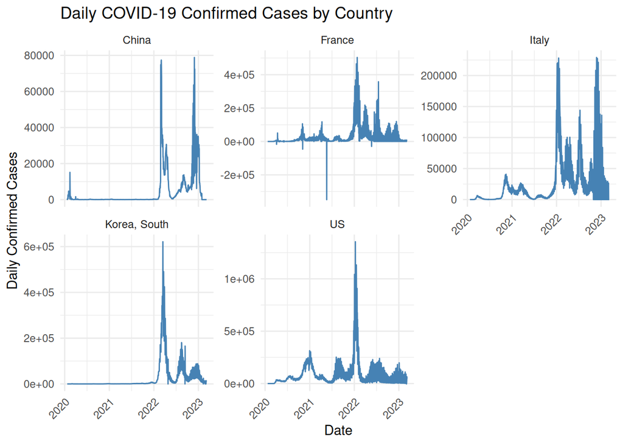

```r
# Step 1: Read and tidy the confirmed cases data
time_series_confirmed <- read_csv("data/time_series_covid19_confirmed_global.csv") %>%
  rename(Province_State = `Province/State`, Country_Region = `Country/Region`)

# Step 2: Reshape to long format and convert date
time_series_confirmed_long <- time_series_confirmed %>%
  pivot_longer(
    cols = matches("^\\d"),  # selects all date columns
    names_to = "Date",
    values_to = "Confirmed"
  ) %>%
  mutate(Date = mdy(Date))

# Step 3: Calculate daily confirmed cases
time_series_confirmed_long_daily <- time_series_confirmed_long %>%
  group_by(Country_Region, Date) %>%
  summarise(confirmed = sum(Confirmed), .groups = "drop") %>%
  arrange(Country_Region, Date) %>%
  group_by(Country_Region) %>%
  mutate(Daily = confirmed - lag(confirmed, default = 0))

# Step 4: Plot using facet_wrap with free y-axis
countries_to_plot <- c("China", "France", "Italy", "Korea, South", "US")

time_series_confirmed_long_daily %>%
  filter(Country_Region %in% countries_to_plot) %>%
  ggplot(aes(x = Date, y = Daily)) +
  geom_line(color = "steelblue") +
  facet_wrap(~ Country_Region, scales = "free_y") +
  labs(
    title = "Daily COVID-19 Confirmed Cases by Country",
    x = "Date",
    y = "Daily Confirmed Cases"
  ) +
  theme_minimal() +
  theme(axis.text.x = element_text(angle = 45, hjust = 1))
```

# Exercise 3

Using the daily count of confirmed cases, make a single graph with 5 countries of your choosing.

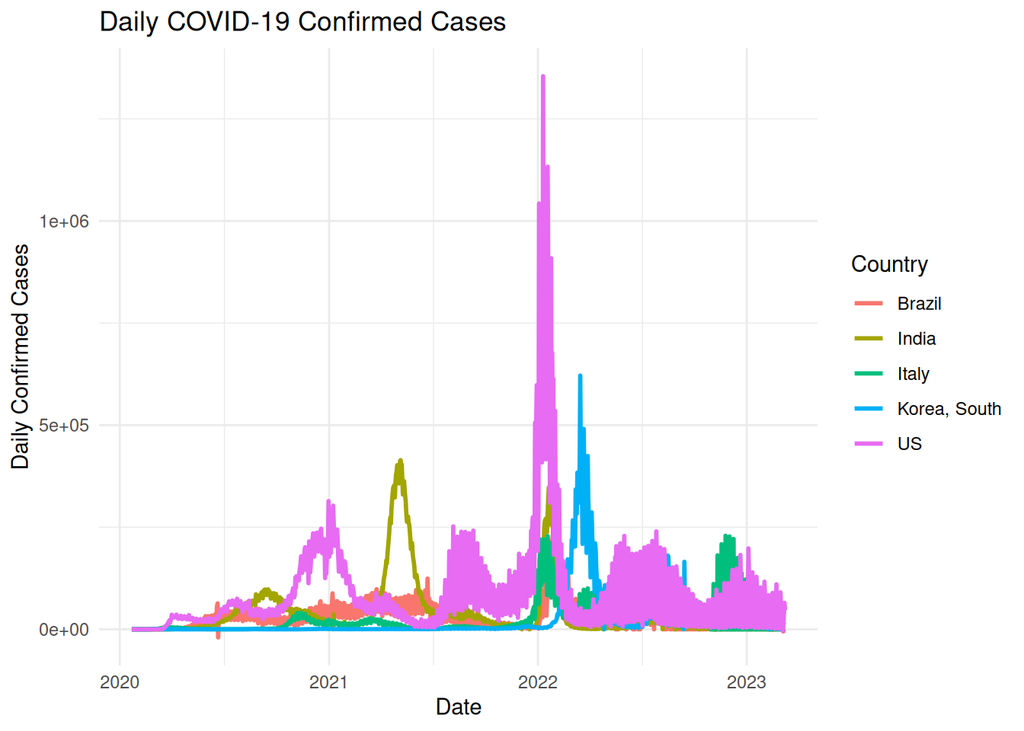

```r
selected_countries <- c("US", "India", "Brazil", "Italy", "Korea, South")

time_series_confirmed_long_daily %>%
  filter(Country_Region %in% selected_countries) %>%
  ggplot(aes(x = Date, y = Daily, color = Country_Region)) +
  geom_line(size = 1) +
  labs(
    title = "Daily COVID-19 Confirmed Cases",
    x = "Date",
    y = "Daily Confirmed Cases",
    color = "Country"
  ) +
  theme_minimal()
```

# Exercise 4

Plot the cumulative deaths in the US, Canada and Mexico (you will need to download time_series_covid19_deaths_global.csv)

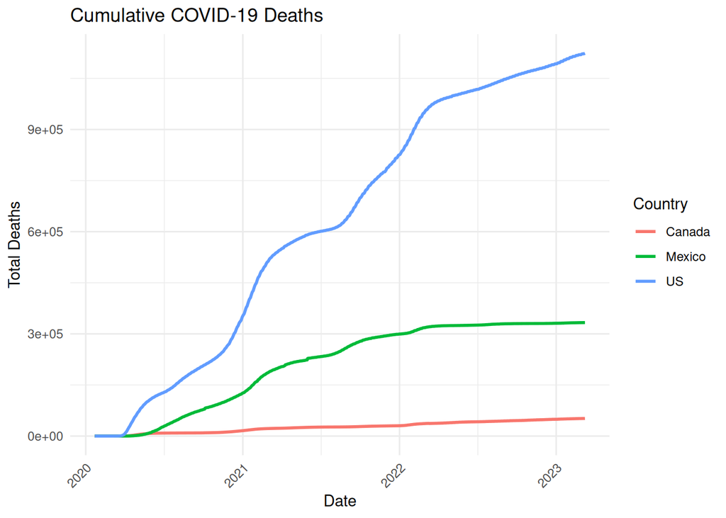

```r
# Step 1: Download the deaths dataset
if (!dir.exists("data")) dir.create("data")

download.file(
  url = "https://raw.githubusercontent.com/CSSEGISandData/COVID-19/master/csse_covid_19_data/csse_covid_19_time_series/time_series_covid19_deaths_global.csv",
  destfile = "data/time_series_covid19_deaths_global.csv"
)

# Step 2: Read and tidy the data
library(readr)
library(dplyr)
library(tidyr)
library(lubridate)
library(ggplot2)

time_series_deaths <- read_csv("data/time_series_covid19_deaths_global.csv") %>%
  rename(Province_State = `Province/State`, Country_Region = `Country/Region`) %>%
  pivot_longer(
    cols = matches("^\\d"),  # selects all date columns
    names_to = "Date",
    values_to = "Deaths"
  ) %>%
  mutate(Date = mdy(Date))

# Step 3: Aggregate cumulative deaths by country and date
deaths_summary <- time_series_deaths %>%
  group_by(Country_Region, Date) %>%
  summarise(deaths = sum(Deaths), .groups = "drop")

# Step 4: Plot cumulative deaths for US, Canada, and Mexico
selected_countries <- c("US", "Canada", "Mexico")

deaths_summary %>%
  filter(Country_Region %in% selected_countries) %>%
  ggplot(aes(x = Date, y = deaths, color = Country_Region)) +
  geom_line(size = 1) +
  labs(
    title = "Cumulative COVID-19 Deaths",
    x = "Date",
    y = "Total Deaths",
    color = "Country"
  ) +
  theme_minimal() +
  theme(axis.text.x = element_text(angle = 45, hjust = 1))
```

# Exercise 5

Make a graph with the countries of your choice using the daily deaths data

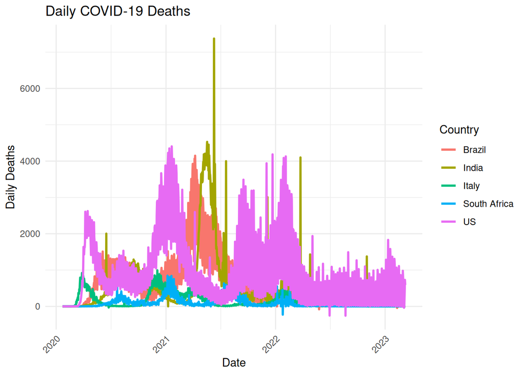

```r
if (!dir.exists("data")) dir.create("data")

download.file(
  url = "https://raw.githubusercontent.com/CSSEGISandData/COVID-19/master/csse_covid_19_data/csse_covid_19_time_series/time_series_covid19_deaths_global.csv",
  destfile = "data/time_series_covid19_deaths_global.csv"
)

time_series_deaths <- readr::read_csv("data/time_series_covid19_deaths_global.csv") %>%
  dplyr::rename(Province_State = `Province/State`, Country_Region = `Country/Region`) %>%
  tidyr::pivot_longer(
    cols = tidyselect::matches("^\\d"),
    names_to = "Date",
    values_to = "Deaths"
  ) %>%
  dplyr::mutate(Date = lubridate::mdy(Date))

daily_deaths <- time_series_deaths %>%
  dplyr::group_by(Country_Region, Date) %>%
  dplyr::summarise(deaths = sum(Deaths), .groups = "drop") %>%
  dplyr::arrange(Country_Region, Date) %>%
  dplyr::group_by(Country_Region) %>%
  dplyr::mutate(Daily_Deaths = deaths - dplyr::lag(deaths, default = 0))

selected_countries <- c("US", "Brazil", "India", "Italy", "South Africa")

daily_deaths %>%
  dplyr::filter(Country_Region %in% selected_countries) %>%
  ggplot2::ggplot(aes(x = Date, y = Daily_Deaths, color = Country_Region)) +
  ggplot2::geom_line(size = 1) +
  ggplot2::labs(
    title = "Daily COVID-19 Deaths",
    x = "Date",
    y = "Daily Deaths",
    color = "Country"
  ) +
  ggplot2::theme_minimal() +
  ggplot2::theme(axis.text.x = element_text(angle = 45, hjust = 1))
```

# Exercise 6

Make an animation of your choosing (do not use a graph with geom_smooth)

```r
library(gganimate)
library(ggplot2)
library(dplyr)
library(gifski)
```

```r
time_series_deaths_confirmed <- read_csv("data/time_series_covid19_deaths_global.csv")|>
  rename(Province_State = "Province/State", Country_Region = "Country/Region")

time_series_deaths_long <- time_series_deaths_confirmed |>
    pivot_longer(-c(Province_State, Country_Region, Lat, Long),
        names_to = "Date", values_to = "Confirmed")

time_series_deaths_long$Date <- mdy(time_series_deaths_long$Date)
```

[figure not shown]